# MPDW_ARCH

Jonathan Marjono

2023-12-07

# Library/packages

```r
library(readxl) #membaca excel
library(openxlsx)
library(astsa)
library(dynlm) #time series regression
library(broom) #LM test
library(FinTS) #ARCH test
library(forecast)
library(tseries)
library(TTR)
library(TSA)
library(rugarch)
```

```r
library(ggplot2)
library(tsibble)
library(tseries)
library(MASS)
library(aTSA)
library(graphics)
```

# Memasukkan data

```r
#Path and dataset
path = "D:/Semester 5/MPDW/Project/"
df_average <- read.csv(paste(path, "Rata Harian.csv", sep=""))[,2:3]
```

# Plot data time series

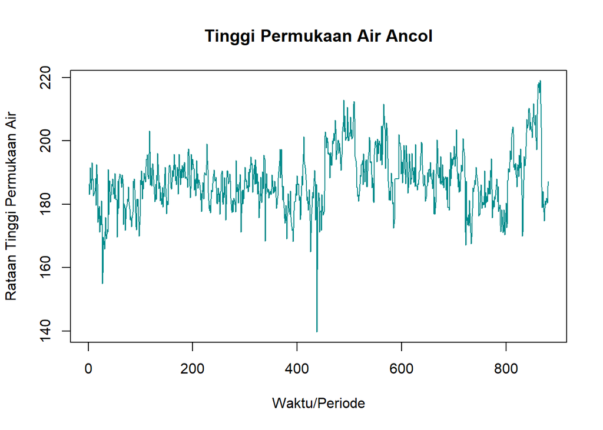

```r
df_average.ts <- ts(df_average$Rataan.Ketinggian.Air.Laut)

plot.ts(df_average.ts, lty=1, lwd=1, xlab="Waktu/Periode", ylab="Rataan Tinggi Permukaan Air", main="Tinggi Permukaan Air Ancol", col= "darkcyan")
```

# Mengecek pola seasonal

Memeriksa adanya efek seasonal dalam keseluruhan data rataan tinggi permukaan air laut. Prinsipnya: bila ada pola tertentu akan dipakai “Seasonal” effect. Bila ada Seasonal effect maka sebagai contoh ARIMA -> SARIMA, ARIMAX -> SARIMAX. Dengan “S” sebagai faktor season.

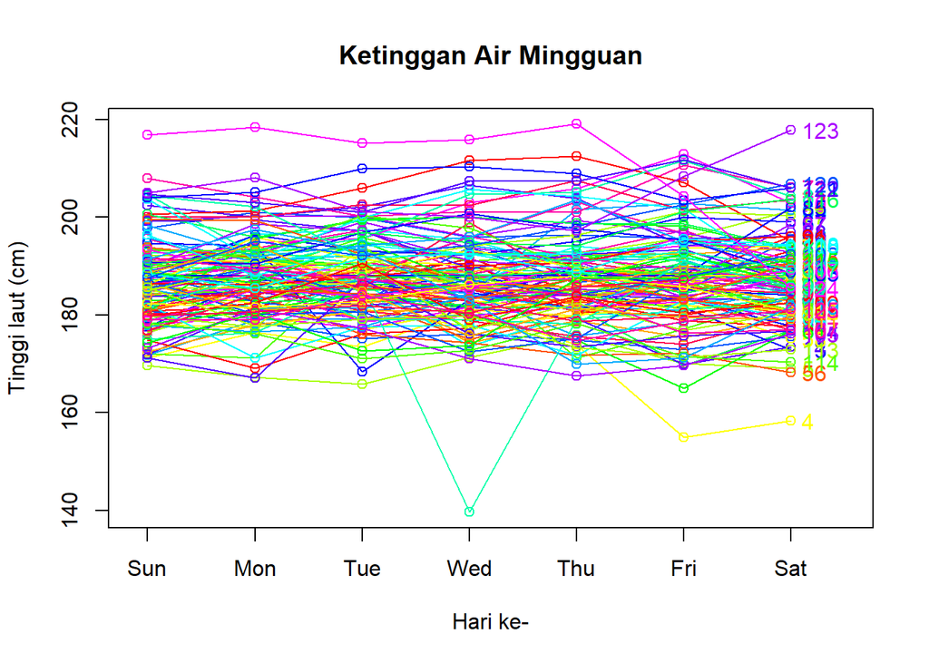

```r
seasonplot(df_average.ts,7,
  main="Ketinggan Air Mingguan",
  xlab = "Hari ke-",
  ylab = "Tinggi laut (cm)", col=rainbow(18),
  year.labels=TRUE)
```

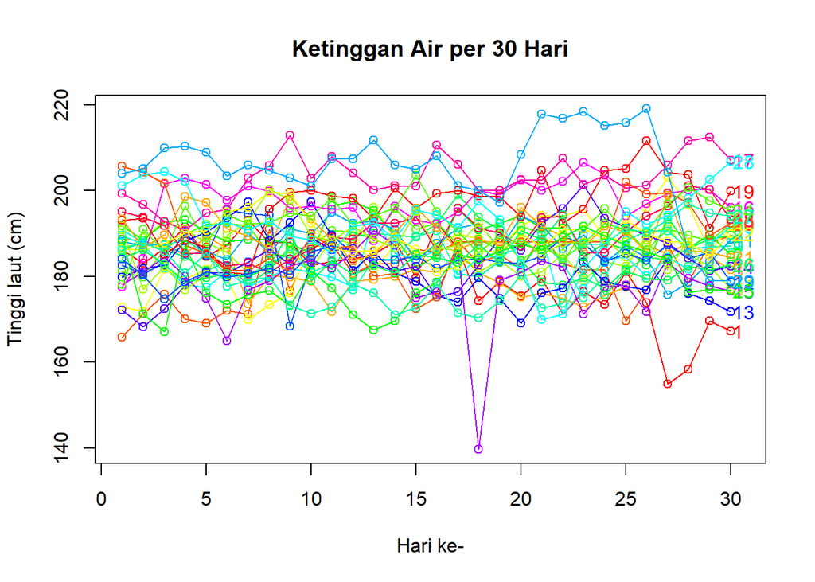

```r
seasonplot(df_average.ts,30,
  main="Ketinggan Air per 30 Hari",
  xlab = "Hari ke-",
  ylab = "Tinggi laut (cm)", col=rainbow(18),
  year.labels=TRUE)
```

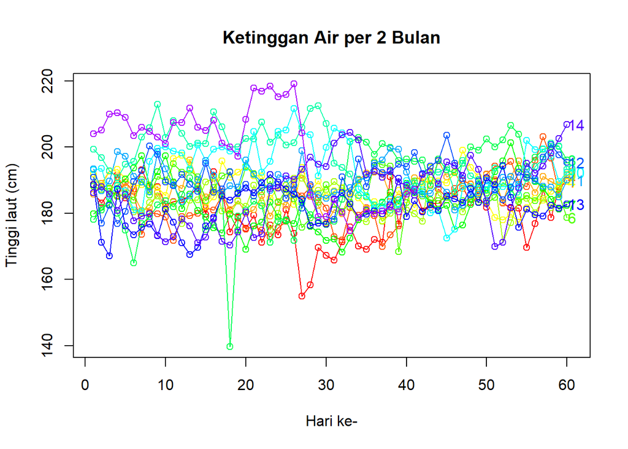

```r
seasonplot(df_average.ts,60,
  main="Ketinggan Air per 2 Bulan",
  xlab = "Hari ke-",
  ylab = "Tinggi laut (cm)", col=rainbow(18),
  year.labels=TRUE)
```

Dilakukan pengujian pola musiman untuk memastikan apakah ada data yang memiliki sebuah pola musiman (seasonal). Secara plot time series dengan seasonal plot tidak ditemukan pola tertentu pada data rataan tinggi permukaan air. Oleh karena itu, dapat kita simpulkan bahwa data tidak memiliki pola musiman.

# Pemotongan data ke 15 bulan

```r
#pakai 15 bulan
Bulan=15
temp=-(Bulan*30-1)+length(df_average$Rataan.Ketinggian.Air.Laut)
df=df_average[temp:length(df_average$Rataan.Ketinggian.Air.Laut),]
df["Tanggal"]=seq(1,length(df$Tanggal))
colnames(df)= c("Periode", "Rataan.Ketinggian.Air.Laut")
df.ts=ts(df$Rataan.Ketinggian.Air.Laut)
```

# Mengecek pola seasonal kembali

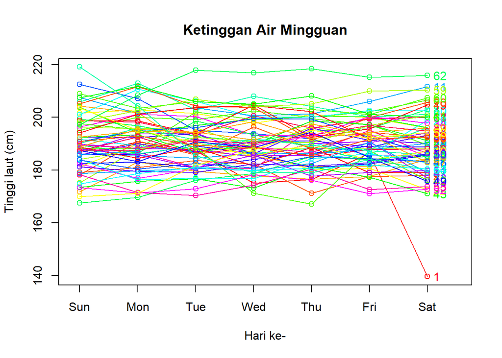

```r
seasonplot(df.ts,7,
  main="Ketinggan Air Mingguan",
  xlab = "Hari ke-",
  ylab = "Tinggi laut (cm)", col=rainbow(18),
  year.labels=TRUE)
```

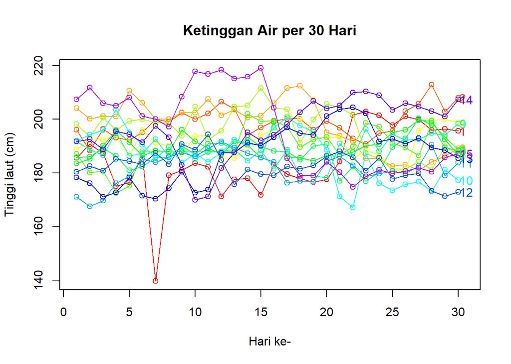

```r
seasonplot(df.ts,30,
  main="Ketinggan Air per 30 Hari",
  xlab = "Hari ke-",
  ylab = "Tinggi laut (cm)", col=rainbow(18),
  year.labels=TRUE)
```

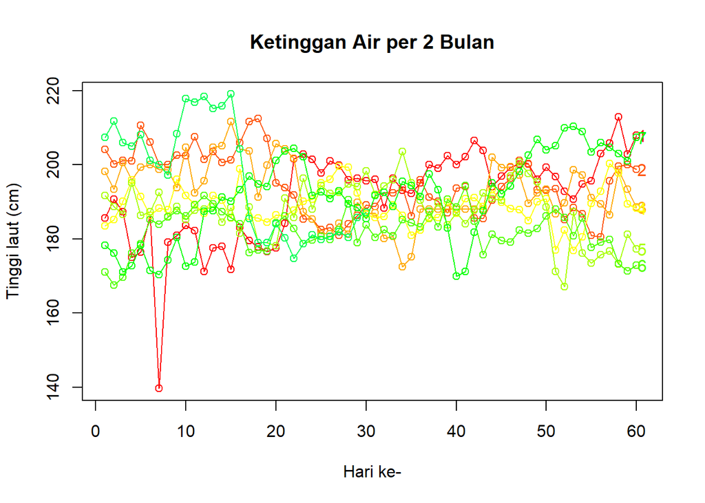

```r
seasonplot(df.ts,60,
  main="Ketinggan Air per 2 Bulan",
  xlab = "Hari ke-",
  ylab = "Tinggi laut (cm)", col=rainbow(18),
  year.labels=TRUE)
```

# Membagi data

Data akan dibagi ke dalam 2 bagian yakni data training dan testing, pembagian data akan dicoba dari memberi garis pada plot untuk mencari splitting terbaik dengan cara berikut ini, namun kali ini diambil 12 bulan vs 3 bulan total 15 bulan.

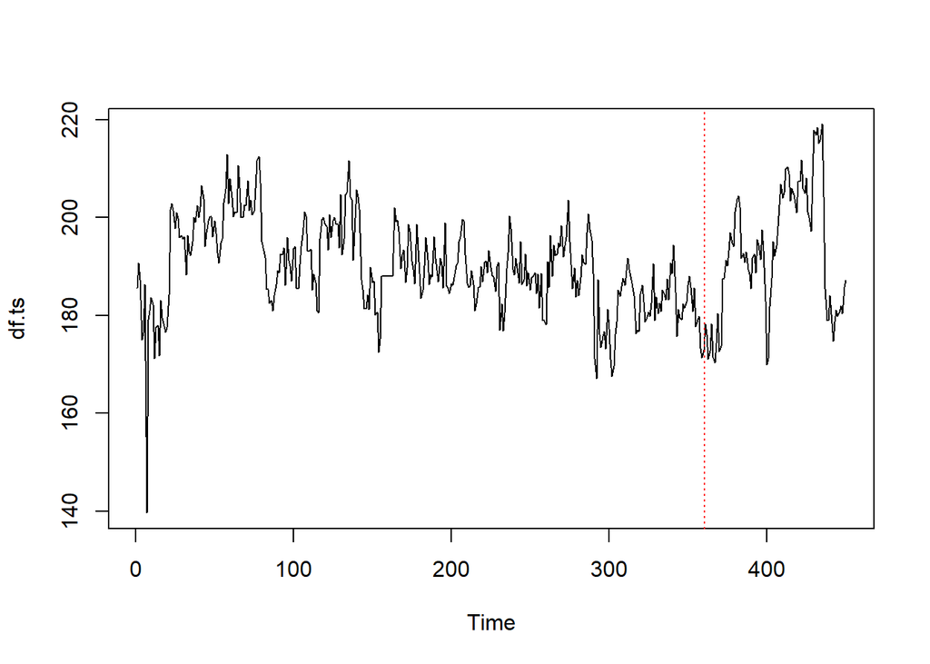

```r
#Gambaran pembagian train test
plot(df.ts)
#points(df.ts)
abline(v=360.5, col="red", lty=3, lwd=1) #area training and testing
```

```r
#Train Test Split
train=df[1:360,]
train.ts=ts(train$Rataan.Ketinggian.Air.Laut)
temp=length(df$Periode)
test=df[361:temp,]
test.ts=ts(test$Rataan.Ketinggian.Air.Laut)
```

# Plot train test

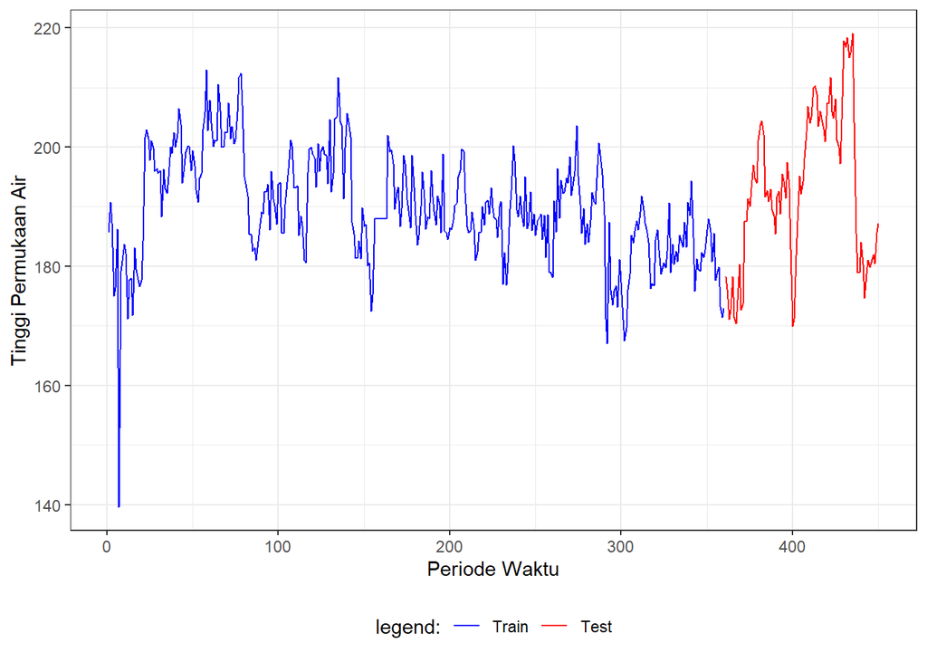

```r
#Plotting Train and Test
ggplot() +
  geom_line(data = test, aes(x = Periode, y = Rataan.Ketinggian.Air.Laut, col = "Test")) +
   geom_line(data = train, aes(x = Periode, y = Rataan.Ketinggian.Air.Laut, col = "Train"))+ labs(x = "Periode Waktu", y = "Tinggi Permukaan Air", color = "Legend") +
  scale_colour_manual(name="legend:", breaks = c("Train", "Test"),
                      values = c("blue", "red")) +
  theme_bw() + theme(legend.position = "bottom", plot.caption = element_text(hjust=0.5, size=12))
```

# Uji stasioneritas (train dataset)

## Dalam rataan

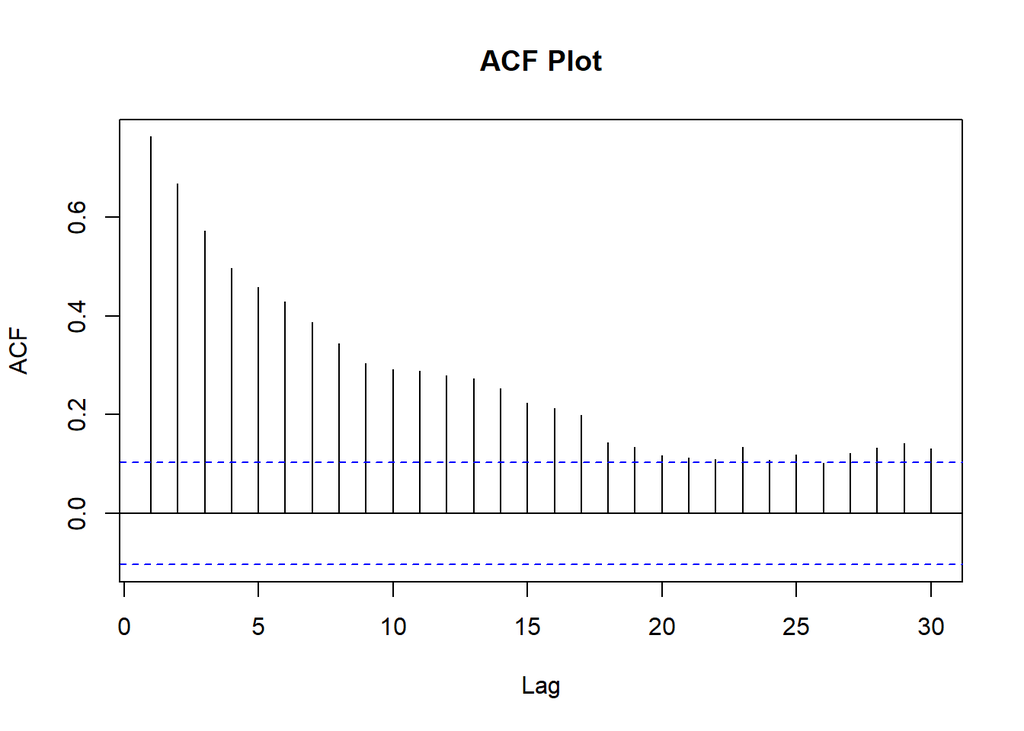

```r
#Dengan plot
acf(train.ts , lag.max=30, main = "ACF Plot") #tidak stasioner dlm rataan
```

```r
#Dengan uji formal
adf.test(train.ts)
```

```
## Augmented Dickey-Fuller Test
## alternative: stationary
##
## Type 1: no drift no trend
##      lag    ADF p.value
## [1,]   0 -0.411   0.526
## [2,]   1 -0.413   0.525
## [3,]   2 -0.391   0.531
## [4,]   3 -0.272   0.566
## [5,]   4 -0.238   0.575
## [6,]   5 -0.313   0.554
## Type 2: with drift no trend
##      lag   ADF p.value
## [1,]   0 -6.75    0.01
## [2,]   1 -4.99    0.01
## [3,]   2 -4.61    0.01
## [4,]   3 -4.44    0.01
## [5,]   4 -3.97    0.01
## [6,]   5 -3.53    0.01
## Type 3: with drift and trend
##      lag   ADF p.value
## [1,]   0 -7.55    0.01
## [2,]   1 -5.68    0.01
## [3,]   2 -5.34    0.01
## [4,]   3 -5.32    0.01
## [5,]   4 -4.89    0.01
## [6,]   5 -4.39    0.01
## ----
## Note: in fact, p.value = 0.01 means p.value <= 0.01
```

Dari pengujian secara plot ACF, nampak garis lag menurun secara perlahan yang mengindikasikan dataset train tidak stasioner dalam rataan. Lalu secara uji formal ADF test untuk data train dapat dikatakan data tidak stasioner dalam rataan dengan melihat type 1: no drift no trend yang memiliki p-value > $\alpha$, sehingga tak tolak $H_0$, dengan $H_a$ stationary. Sehingga data juga tidak stasioner. ADF test hypotheses: $H_0$: The time series is non-stationary. $H_A$: The time series is stationary.

## Dalam ragam/varians

```r
n = length(train.ts)
index <- seq(1:n) #Sampai periode terakhir data train
bc = boxcox(train.ts~index, lambda = seq(0,6,by=1))
```

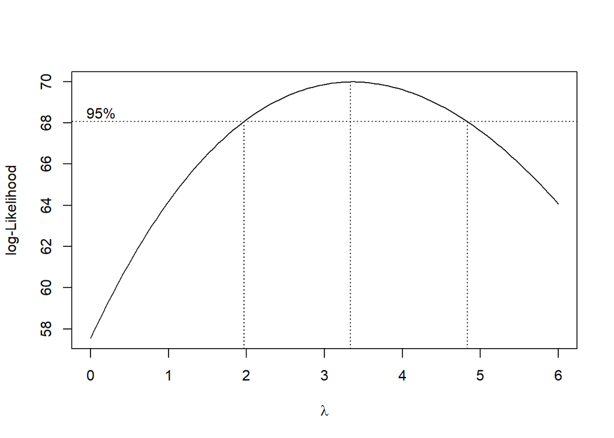

```r
#Nilai Rounded Lambda
lambda <- bc$x[which.max(bc$y)]
best.lambda = bc$x[which(bc$y==max(bc$y))]
best.lambda
```

```
## [1] 3.333333
```

```r
#SK
bc$x[bc$y > max(bc$y) - 1/2 * qchisq(.95,1)]
```

```
##  [1] 2.000000 2.060606 2.121212 2.181818 2.242424 2.303030 2.363636 2.424242
##  [9] 2.484848 2.545455 2.606061 2.666667 2.727273 2.787879 2.848485 2.909091
## [17] 2.969697 3.030303 3.090909 3.151515 3.212121 3.272727 3.333333 3.393939
## [25] 3.454545 3.515152 3.575758 3.636364 3.696970 3.757576 3.818182 3.878788
## [33] 3.939394 4.000000 4.060606 4.121212 4.181818 4.242424 4.303030 4.363636
## [41] 4.424242 4.484848 4.545455 4.606061 4.666667 4.727273 4.787879
```

Pada selang boxcox diatas tidak memuat nilai 1, sehingga tidak stasioner dalam ragam.

# Penanganan stasioneritas

Dasarnya yang ditangani adalah varians dulu dengan boxcox barulah ke differencing dalam hal rataan.

Namun setelah beberapa attempt diperoleh bahwa beberapa asumsi terlanggar yang salah satunya heteroskedasticity terdeteksi. Sehingga akan digunakan model-ARCH/GARCH.

Dengan pemanfaatkan ARCH/GARCH permasalahan dalam ragam tidak perlu ditangani karena dapat tertangani secara langsung dari ARCH/GARCH itu sendiri, kalaupun ditangani hasilnya tidak akan jauh berbeda.

Oleh karena kita akan membandingkan metric akurasi prediksi dengan LSTM, dengan model ARCH/GARCH itu sendiri hal yang akan ditangani cukup ketidakstasioneran dalam rataan sebab ARCH/GARCH tidak dapat memberikan solusi akan kasus tersebut. Setelah ditangani barulah kita menyusun model ARCH/GARCH-nya.

“Differencing aja 1x kan mau make ARCH/GARCH juga, nga ush mikirin ragam ragam”

## Differencing

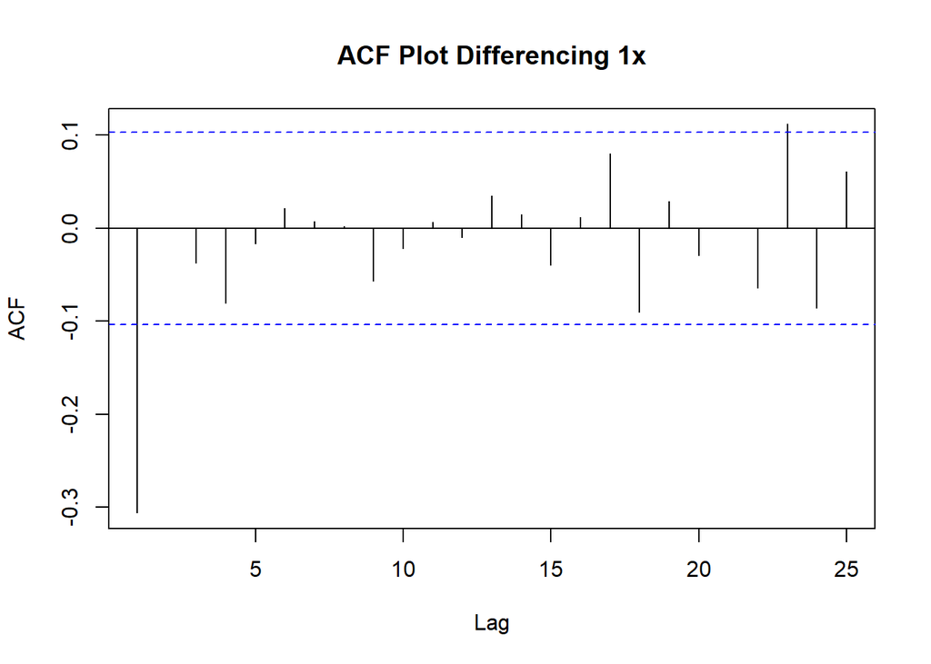

```r
dif_ori <- diff(train.ts, differences = 1)
acf(dif_ori, main = "ACF Plot Differencing 1x")
```

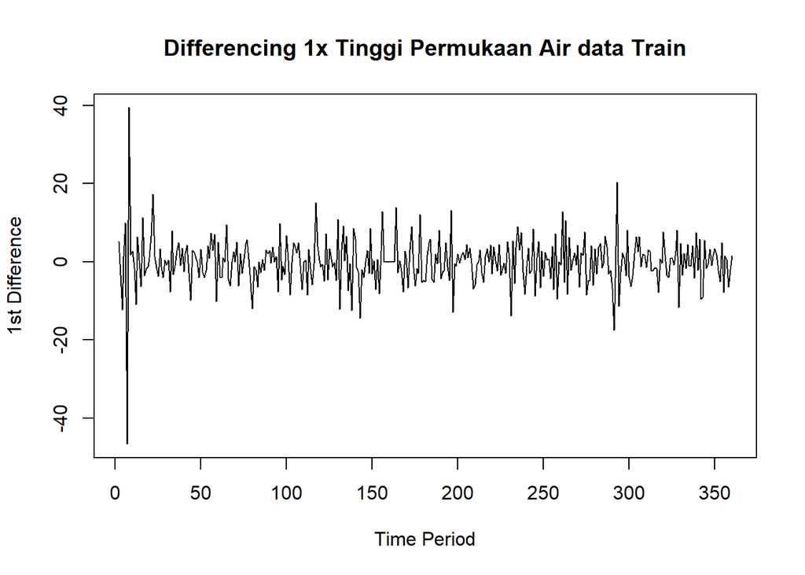

```r
plot.ts(dif_ori, xlab='Time Period', ylab='1st Difference', main="Differencing 1x Tinggi Permukaan Air data Train")
```

Berdasarkan dari plot diatas, sudah stasioner dalam rataan sebab rataan terlihat menyebar/berada pada nilai tertentu. Kemudian secara plot ACF sudah tidak menurun secara perlahan.

# Model mean terbaik (tentatif)

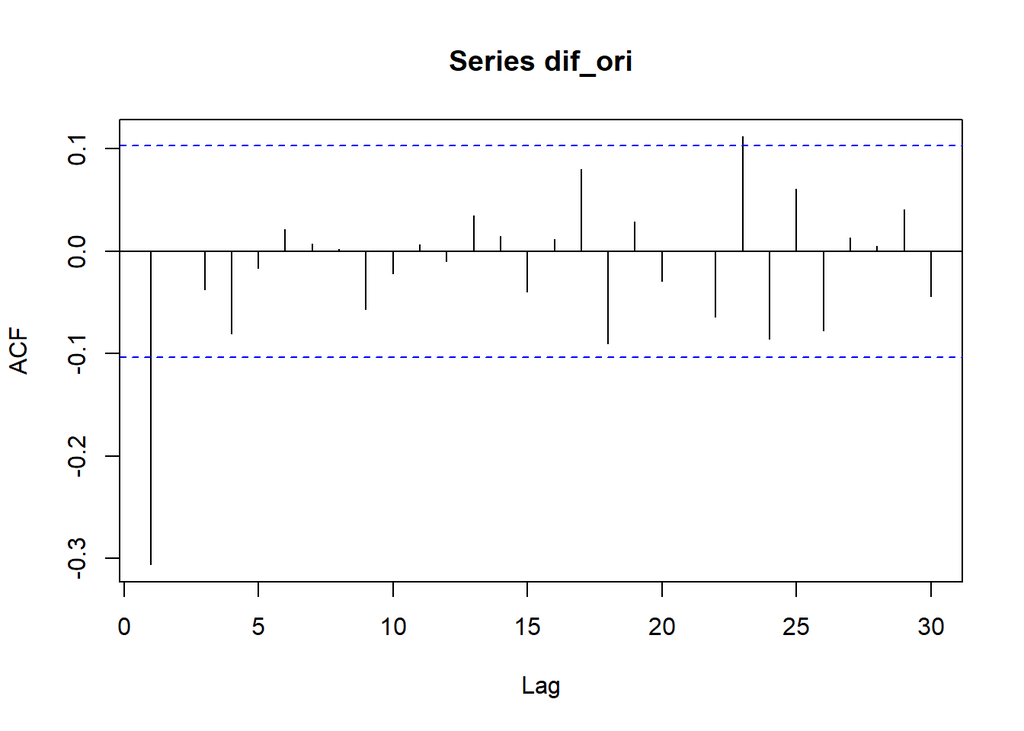

```r
acf(dif_ori, lag.max=30) #ARIMA(0,1,1)
```

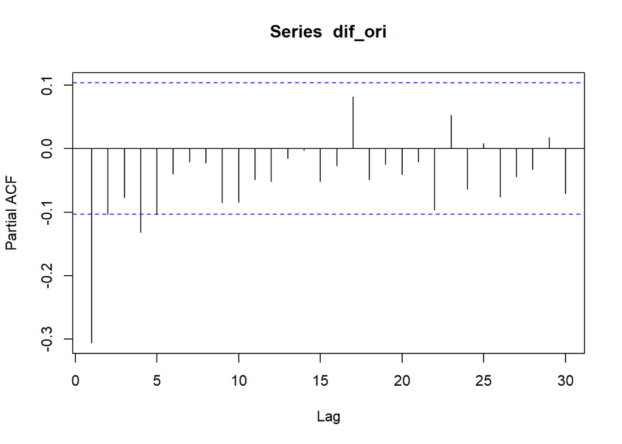

```r
pacf(dif_ori, lag.max=30) #ARIMA(1,1,0) ARIMA(4,1,0)
```

```r
eacf(dif_ori) #ARIMA(0,1,1), ARIMA(0,1,2), ARIMA(1,1,2)
```

```
## AR/MA
##   0 1 2 3 4 5 6 7 8 9 10 11 12 13
## 0 x o o o o o o o o o o  o  o  o
## 1 x o o o o o o o o o o  o  o  o
## 2 x o o o o o o o o o o  o  o  o
## 3 x x x x o o o o o o o  o  o  o
## 4 x x o o o o o o o o o  o  o  o
## 5 x x o o o o o o o o o  o  o  o
## 6 x o o o x o o o o o o  o  o  o
## 7 x o o o x x o o o o o  o  o  o
```

# Pemilihan model tentatif

```r
modelARIMA011 <- Arima(train.ts, order=c(0,1,1), method = "ML")
modelARIMA110 <- Arima(train.ts, order=c(1,1,0), method = "ML")
modelARIMA410 <- Arima(train.ts, order=c(4,1,0), method = "ML")
modelARIMA012 <- Arima(train.ts, order=c(0,1,2), method = "ML")
modelARIMA112 <- Arima(train.ts, order=c(1,1,2), method = "ML")
```

```r
Model <- c("ARIMA(0,1,1)", "ARIMA(1,1,0)", "ARIMA(4,1,0)", "ARIMA(0,1,2)","ARIMA(1,1,2)")
AIC <- round(c(modelARIMA011$aic, modelARIMA110$aic, modelARIMA410$aic, modelARIMA012$aic, modelARIMA112$aic),2)

perbandingan_AIC <- as.data.frame(cbind(Model,AIC))
perbandingan_AIC
```

```
##          Model     AIC
## 1 ARIMA(0,1,1) 2291.26
## 2 ARIMA(1,1,0) 2298.44
## 3 ARIMA(4,1,0) 2292.32
## 4 ARIMA(0,1,2)  2290.8
## 5 ARIMA(1,1,2) 2277.54
```

Akan dipilih model tentatif dengan AIC terkecil yakni ARIMA(1,1,2), lalu diperiksa apakah semua parameternya signifikan.

```r
#Memeriksa signifikansi parameter
lmtest::coeftest(modelARIMA112)
```

```
##
## z test of coefficients:
##
##      Estimate Std. Error  z value  Pr(>|z|)
## ar1  0.832399   0.054195  15.3594 < 2.2e-16 ***
## ma1 -1.232088   0.079338 -15.5295 < 2.2e-16 ***
## ma2  0.249363   0.071650   3.4803 0.0005008 ***
## ---
## Signif. codes:  0 '***' 0.001 '**' 0.01 '*' 0.05 '.' 0.1 ' ' 1
```

Karena semuanya signifikan akan sejauh ini model tentatif terbaiknya adalah ARIMA(1,1,2). Syntax diatas dapat dicobakan untuk model tentatif lainnya untuk memeriksa parameternya signifikan tidak.

# Overfitting

Konsep ini dipakai dengan meningkatkan ARIMA(p+1,d,q) ataupun ARIMA(p,d,q+1) dari model tentatif terbaik sebelum dilakukan overfitting.

Maka kita akan overfit ARIMA(1,1,2) ke ARIMA(2,1,2) dan ARIMA(1,1,3).

```r
modelARIMA212 <- Arima(train.ts, order=c(2,1,2), method = "ML")
modelARIMA113 <- Arima(train.ts, order=c(1,1,3), method = "ML")

Model <- c("ARIMA(1,1,2)", "ARIMA(2,1,2)", "ARIMA(1,1,3)")
AIC <- round(c(modelARIMA112$aic,modelARIMA212$aic, modelARIMA113$aic),2)

perbandingan_AIC <- as.data.frame(cbind(Model,AIC))
perbandingan_AIC
```

```
##          Model     AIC
## 1 ARIMA(1,1,2) 2277.54
## 2 ARIMA(2,1,2)  2279.2
## 3 ARIMA(1,1,3) 2279.26
```

```r
#Memeriksa signifikansi parameter
lmtest::coeftest(modelARIMA212)
```

```
##
## z test of coefficients:
##
##      Estimate Std. Error z value Pr(>|z|)
## ar1  0.641226   0.312765  2.0502 0.040346 *
## ar2  0.137071   0.214606  0.6387 0.523011
## ma1 -1.045279   0.315766 -3.3103 0.000932 ***
## ma2  0.069507   0.300745  0.2311 0.817223
## ---
## Signif. codes:  0 '***' 0.001 '**' 0.01 '*' 0.05 '.' 0.1 ' ' 1
```

```r
lmtest::coeftest(modelARIMA113)
```

```
##
## z test of coefficients:
##
##      Estimate Std. Error  z value  Pr(>|z|)
## ar1  0.805835   0.085140   9.4648 < 2.2e-16 ***
## ma1 -1.208562   0.101578 -11.8979 < 2.2e-16 ***
## ma2  0.268541   0.083253   3.2256  0.001257 **
## ma3 -0.038505   0.074311  -0.5182  0.604349
## ---
## Signif. codes:  0 '***' 0.001 '**' 0.01 '*' 0.05 '.' 0.1 ' ' 1
```

Karena memiliki AIC yang lebih besar serta ada parameter yang tidak signifikan maka tetap dimanfaatkan ARIMA(1,1,2) sebagai base model untuk ARCH/GARCH.

# Diagnostik model

```r
#Model ARIMA(1,1,2)
model2.of <- Arima(train.ts, order=c(1,1,2),method="ML")
summary(model2.of) #AIC=2277.54
```

```
## Series: train.ts
## ARIMA(1,1,2)
##
## Coefficients:
##          ar1      ma1     ma2
##       0.8324  -1.2321  0.2494
## s.e.  0.0542   0.0793  0.0716
##
## sigma^2 = 32.76:  log likelihood = -1134.77
## AIC=2277.54   AICc=2277.65   BIC=2293.07
##
## Training set error measures:
##                       ME     RMSE      MAE        MPE     MAPE      MASE
## Training set -0.09413134 5.692173 4.059919 -0.1410094 2.169567 0.9574714
##                      ACF1
## Training set -0.005475836
```

```r
#Signifikansi koefisien
lmtest::coeftest(model2.of) #Seluruh parameter signifikan
```

```
##
## z test of coefficients:
##
##      Estimate Std. Error  z value  Pr(>|z|)
## ar1  0.832399   0.054195  15.3594 < 2.2e-16 ***
## ma1 -1.232088   0.079338 -15.5295 < 2.2e-16 ***
## ma2  0.249363   0.071650   3.4803 0.0005008 ***
## ---
## Signif. codes:  0 '***' 0.001 '**' 0.01 '*' 0.05 '.' 0.1 ' ' 1
```

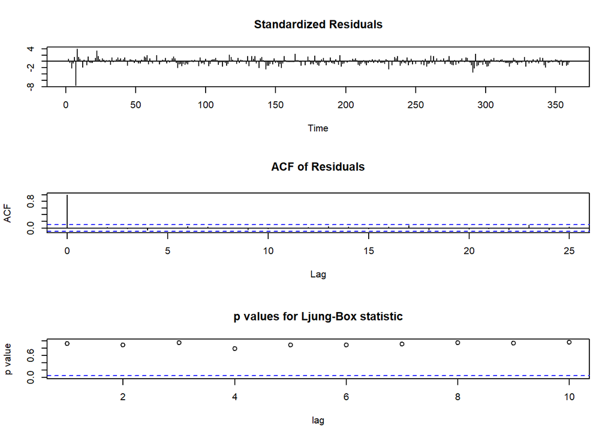

```r
tsdiag(model2.of) #sisaan terlihat acak dan bebas
```

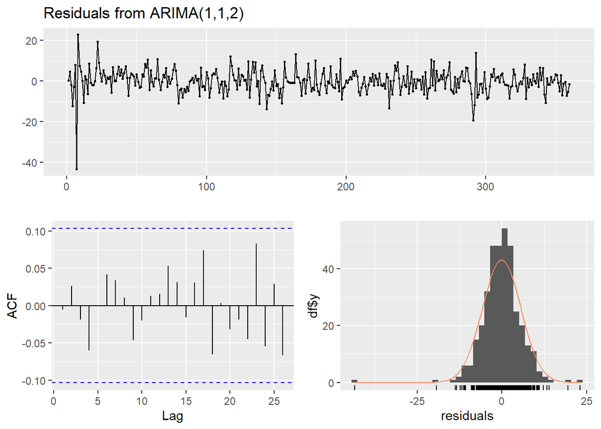

```
##
##  Ljung-Box test
##
## data:  Residuals from ARIMA(1,1,2)
## Q* = 3.7985, df = 7, p-value = 0.8027
##
## Model df: 3.   Total lags used: 10
```

```r
checkresiduals(model2.of)
```